# chap7_annotations

J.H AHN

2022 1 10

### 7.1 Adding text annotations

`annotate()`는 여러가지 geometric object를 추가할 수 있다.  
아래는 `geom = "text"`를 사용한 예이다.

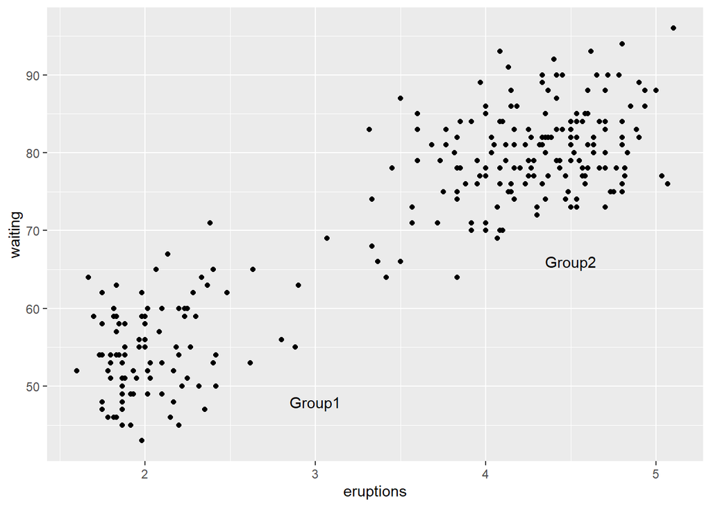

```r
faithful %>%
  ggplot(aes(x = eruptions, y = waiting)) +
  geom_point() +
  annotate("text", x = 3, y = 48, label = "Group1") +
  annotate("text", x = 4.5, y = 66, label = "Group2")
```

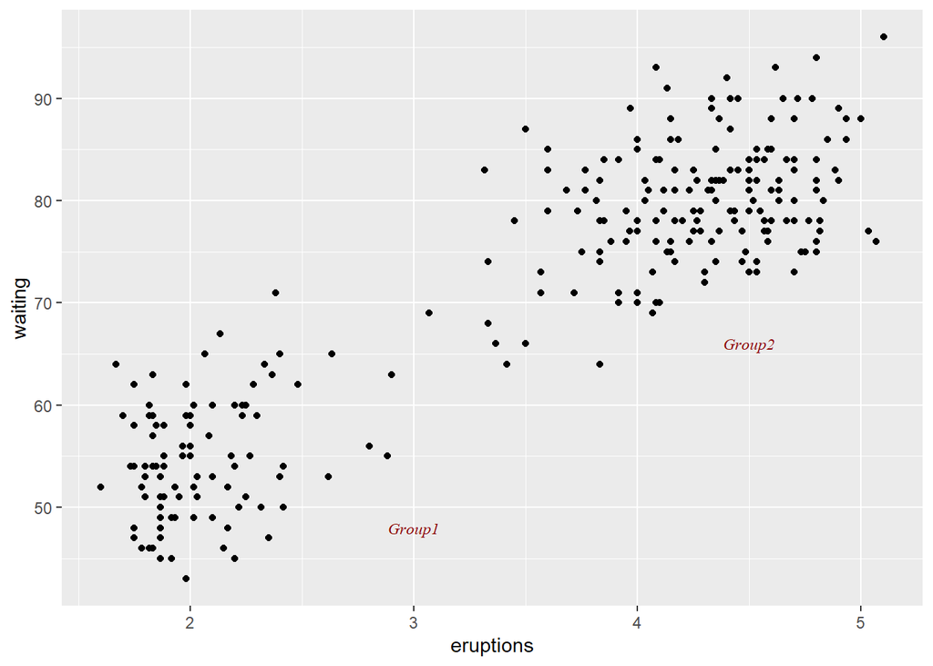

```r
faithful %>%
  ggplot(aes(x = eruptions, y = waiting)) +
  geom_point() +
  annotate("text", x = 3, y = 48, label = "Group1", family = "serif",
           fontface = "italic", color = "#8B0000", size = 3) +
  annotate("text", x = 4.5, y = 66, label = "Group2", family = "serif",
           fontface = "italic", color = "#8B0000", size = 3)
```

개별 text object를 추가하기 원할 때 `geom_text()` **사용하지 않도록 주의해야 한다.**  
`annotate(geom = "text")`는 하나의 text object를 추가하는데 반해, `geom_text()`는 데이터를 기초로 다수의 text object를 생성한다.  
만약 `geom_text()`를 사용했다면 text는 같은 위치에 한 데이터당 하나씩 매우 많이 겹쳐져서 출력될 것이다.

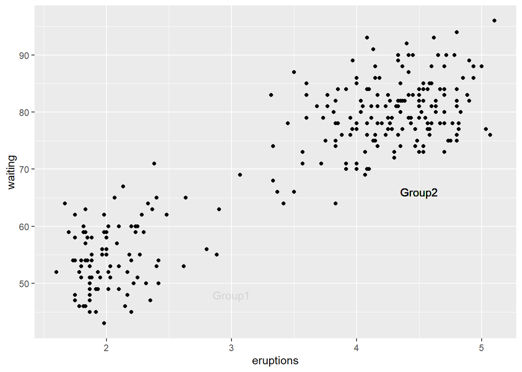

```r
faithful %>%
  ggplot(aes(x = eruptions, y = waiting)) +
  geom_point() +
  annotate("text", x = 3, y = 48, label = "Group1", alpha = 0.1) +
  geom_text(x = 4.5, y = 66, label = "Group2", alpha = 0.1)
```

만약 축이 연속형이라면 **Inf**, **-Inf**를 사용하여 주석을 plotting영역 모서리에 위치 시킬 수 있다.  
**hjust**, **vjust**를 사용하여 글자의 상대위치를 조정할 수도 있고 default로 두면 글자는 모서리에 중간맞춤으로 위치한다.

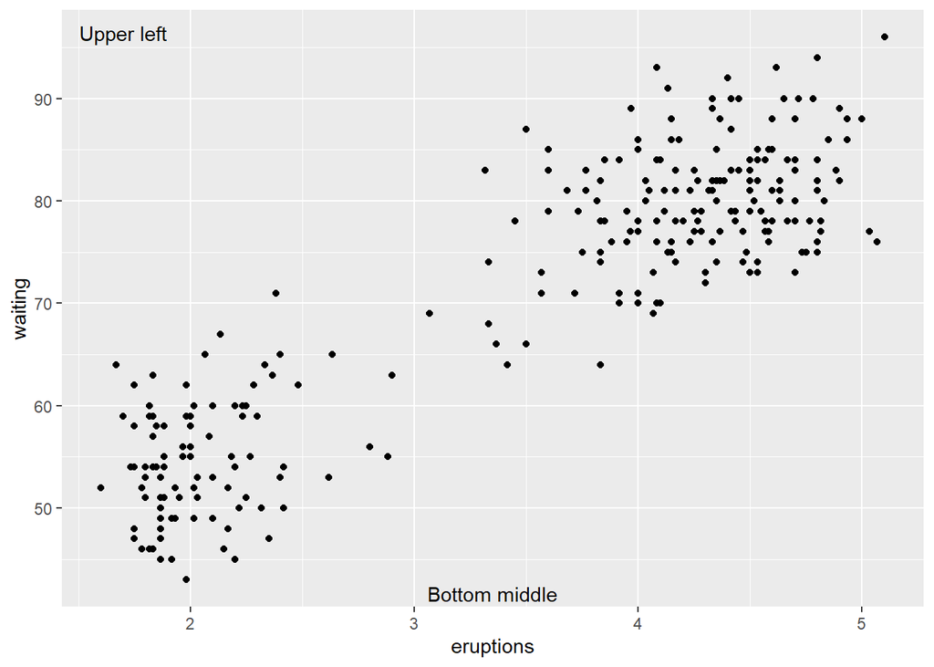

```r
faithful %>%
  ggplot(aes(x = eruptions, y = waiting)) +
  geom_point() +
  annotate("text", x = -Inf, y = Inf, label = "Upper left",
           hjust = -0.2, vjust = 2) +
  annotate("text", x = mean(range(faithful$eruptions)), y = -Inf,
           label = "Bottom middle", vjust = -0.4)
```

### 7.2 Using mathmatical expressions in annotations

주석에 수식을 넣고 싶을 때는 `annotate(geom = "text")`에 `parse = TURE`를 설정하면 된다.  
아래 예제에는 -3에서 3까지의 Normal distribution을 `dnorm()`으로 만들어 plotting을 하고 그 위에 수식을 넣는 것이다.  
`dnorm()`은 데이터, 평균값, 표준편차를 입력하여 Normal distribution density를 반환하는 함수이다.

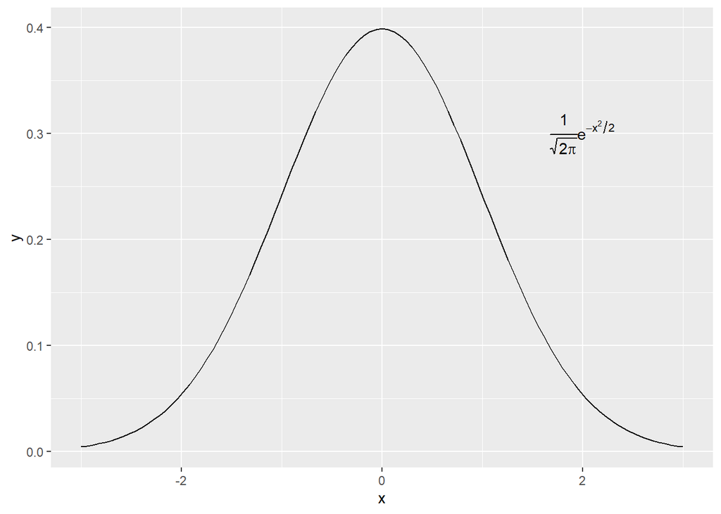

```r
nord <- ggplot(data.frame(x = c(-3,3)), aes(x = x)) + stat_function(fun = dnorm)

nord + annotate("text", x = 2, y = 0.3, parse = TRUE,
                label = "frac(1, sqrt(2*pi))*e^{-x^2/2}")
```

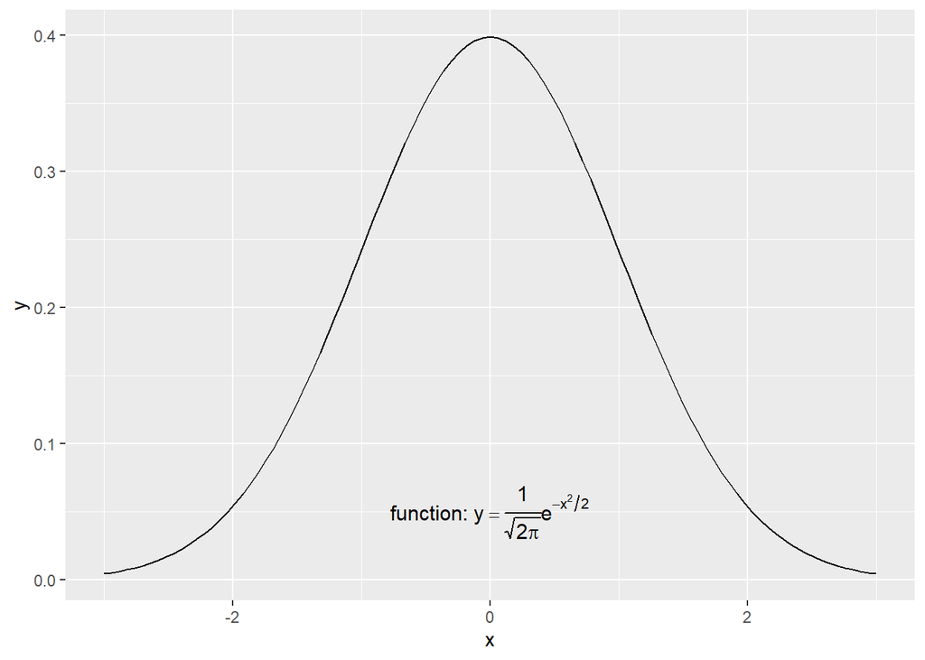

```r
nord + annotate("text", x = 0, y = 0.05, parse = TRUE, size = 4,
                label = "'function: ' * y == frac(1, sqrt(2*pi))*e^{-x^2/2}")
```

### 7.3 Adding lines

그래프에 수평선(`geom_hline()`), 수직선(`geom_vline()`) 혹은 사선(`geom_abline()`)을 넣는 예시는 아래와 같다.

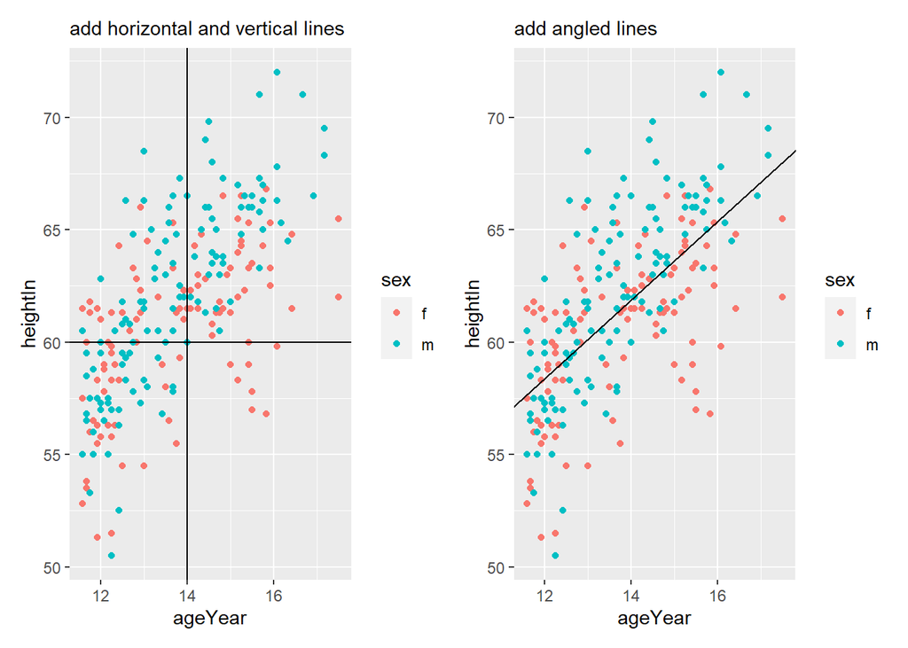

```r
fig_707 <-
  heightweight %>%
  ggplot(aes(x = ageYear, y = heightIn, color = sex)) +
  geom_point()

fig_7071 <-
  fig_707 +
  geom_hline(yintercept = 60) +
  geom_vline(xintercept = 14) +
  labs(subtitle = "add horizontal and vertical lines")

fig_7072 <-
  fig_707 +
  geom_abline(intercept = 37.4, slope = 1.75) +
  labs(subtitle = "add angled lines")


fig_7071 + fig_7072
```

```r
hw_mean_book <- heightweight %>% plyr::ddply("sex", summarise, heightIn = mean(heightIn))

hw_mean_book
```

```
##   sex heightIn
## 1   f 60.52613
## 2   m 62.06000
```

```r
hw_mean <- heightweight %>% group_by(sex) %>% summarise(heightIn = mean(heightIn))

hw_mean
```

```
## # A tibble: 2 x 2
##   sex   heightIn
##   <fct>    <dbl>
## 1 f         60.5
## 2 m         62.1
```

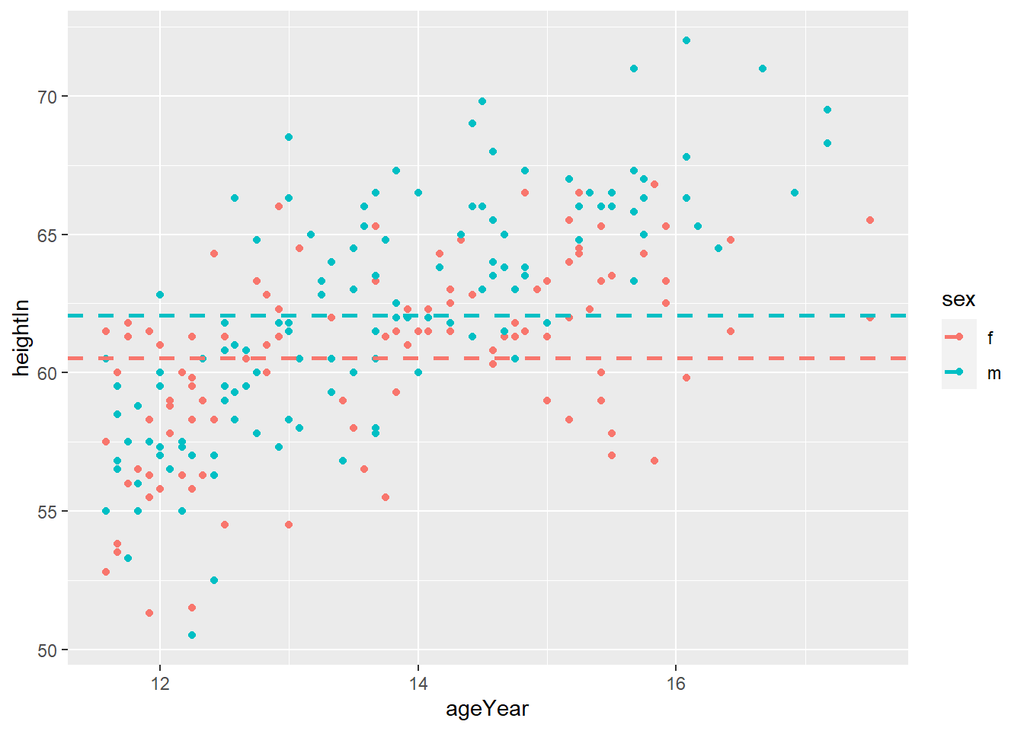

```r
fig_707 +
  geom_hline(aes(yintercept = heightIn, color = sex), data = hw_mean,
             linetype = "dashed", size = 1)
```

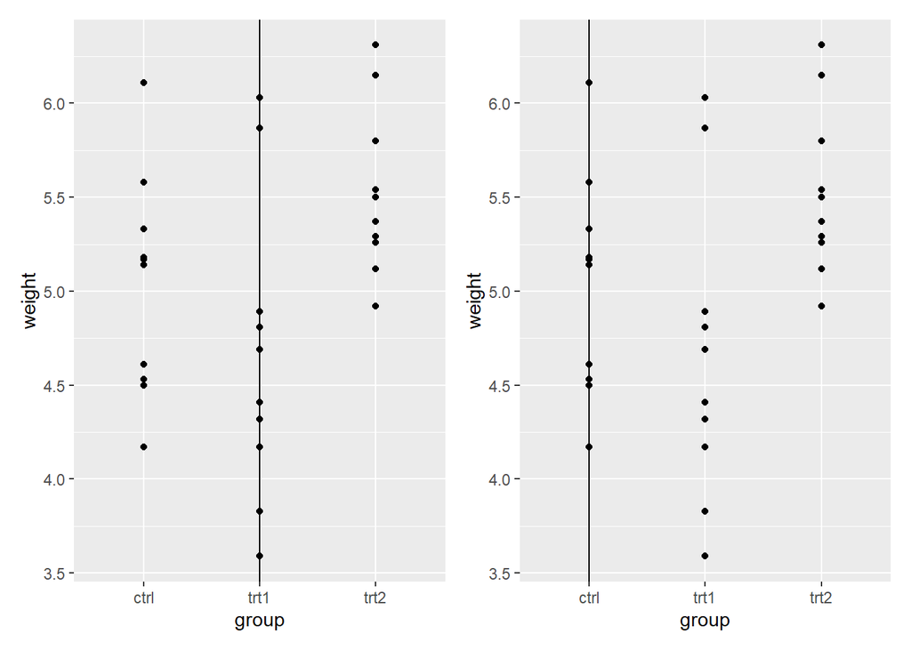

```r
pg <-
  PlantGrowth %>%
  ggplot(aes(x = group, y = weight)) +
  geom_point()

fig7091 <- pg + geom_vline(xintercept = 2)

fig7092 <- pg + geom_vline(xintercept = which(levels(PlantGrowth$group) == "ctrl"))

fig7091 + fig7092
```

### 7.4 Adding line segments and arrows

`annotate("segment")`를 사용는 예를 살펴보자.

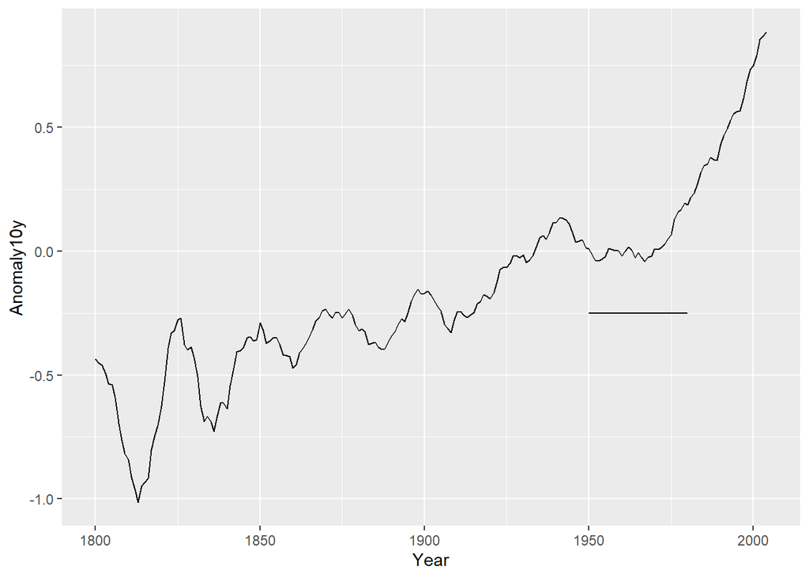

```r
p <-
  climate %>% subset(Source == "Berkeley") %>%
  ggplot(aes(x = Year, y = Anomaly10y)) +
  geom_line()

p + annotate("segment", x = 1950, xend = 1980, y = -0.25, yend = -0.25)
```

line segment에 `grid` package의 `arrow()`를 사용하여 화살표를 넣을 수도 있다.  
화살표는 angle = 30, length = 0.2inches가 default이다.  
만약 하나 혹은 양쪽 축이 이산형이면 x나 y 위치는 categorical items이 가지는 coordinate value를 사용해야 한다.

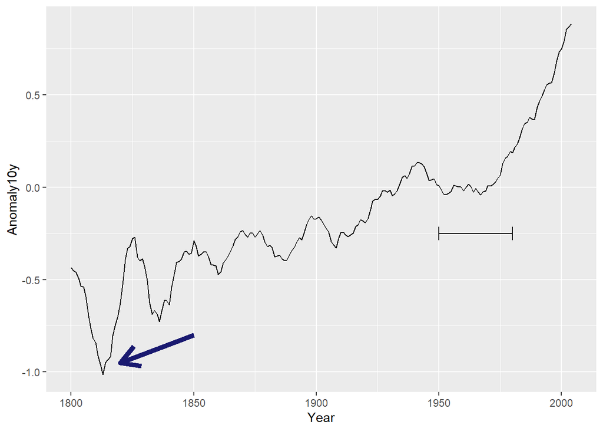

```r
p +
  annotate("segment", x = 1850, xend = 1820, y = -0.8, yend = -0.95,
             color = "#191970", size = 2, arrow = arrow()) +
  annotate("segment", x = 1950, xend = 1980, y = -0.25, yend = -0.25,
           arrow = arrow(ends = "both", angle = 90, length = unit(0.2, "cm")))
```

### 7.5 Adding a shaded rectangle

`annotate("rect")`를 사용한다.

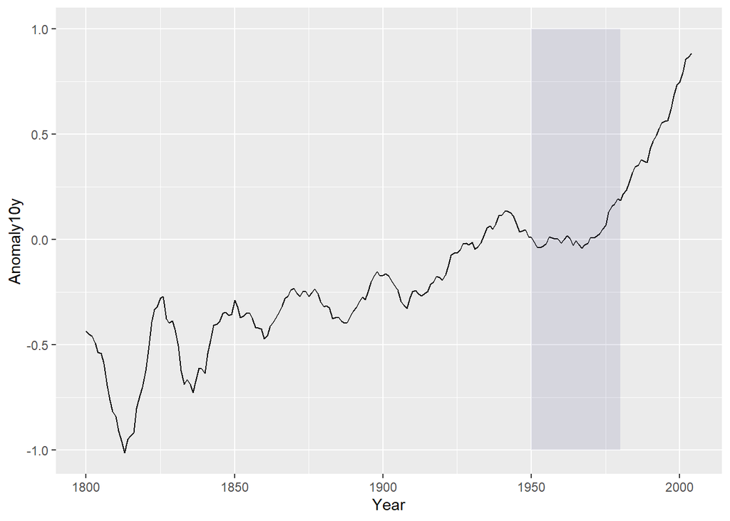

```r
p +
  annotate("rect", xmin = 1950, xmax = 1980, ymin = -1, ymax = 1,
           alpha = 0.1, fill = "#191970")
```

### 7.6 Highlighting an item

```r
pg <-
  PlantGrowth %>%
  mutate(hl = case_when(group == "trt2" ~ "yes", TRUE ~ "no"))

pg
```

```
##    weight group  hl
## 1    4.17  ctrl  no
## 2    5.58  ctrl  no
## 3    5.18  ctrl  no
## 4    6.11  ctrl  no
## 5    4.50  ctrl  no
## 6    4.61  ctrl  no
## 7    5.17  ctrl  no
## 8    4.53  ctrl  no
## 9    5.33  ctrl  no
## 10   5.14  ctrl  no
## 11   4.81  trt1  no
## 12   4.17  trt1  no
## 13   4.41  trt1  no
## 14   3.59  trt1  no
```

[output cut: 16 more lines]

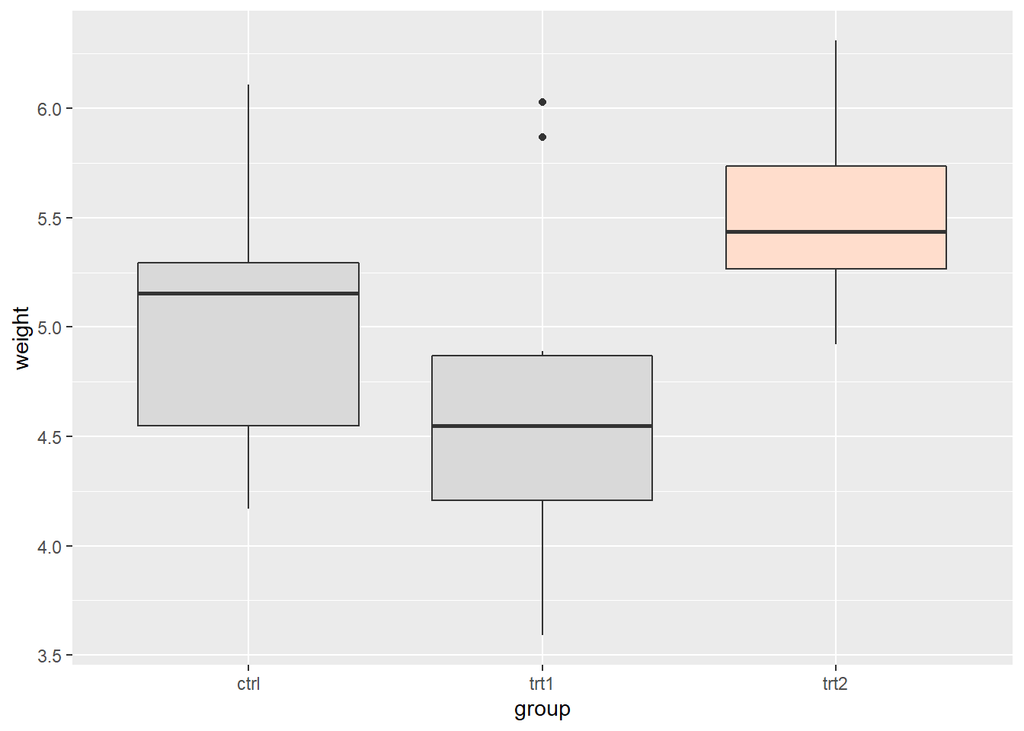

```r
pg %>%
  ggplot(aes(x = group, y = weight, fill = hl)) +
  geom_boxplot() +
  scale_fill_manual(values = c("gray85", "#FFDDCC"), guide = "none")
```

hl열을 만들지 않고 곧바로 group열의 값을 이용해서 그려도 동일한 결과를 얻을 수 있음.

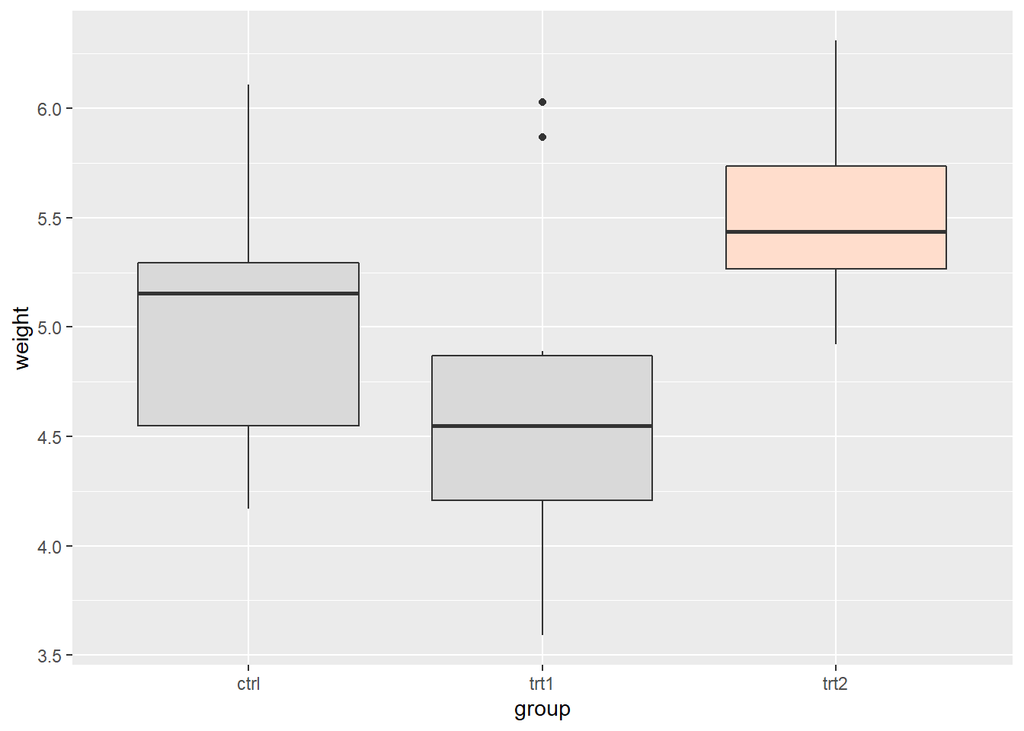

```r
pg %>%
  ggplot(aes(x = group, y = weight, fill = group)) +
  geom_boxplot() +
  scale_fill_manual(values = c("gray85", "gray85", "#FFDDCC"), guide = "none")
```

### 7.7 Adding error bars

`geom_errorbar()`에 `ymin`과 `ymax`를 맵핑하여 만들 수 있다.  
errorbar를 그리는 것은 bar graphs나 line graph와 동일하다.

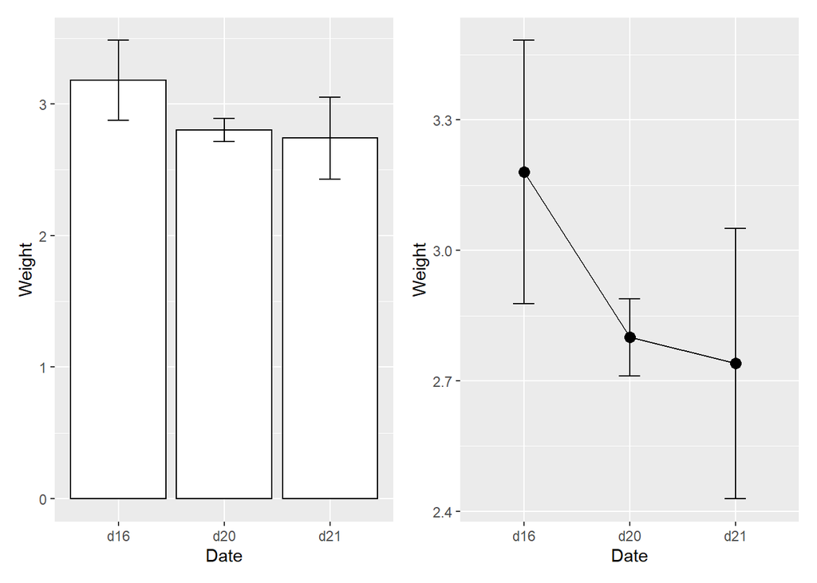

```r
ce <- cabbage_exp %>% subset(Cultivar == "c39")

fig_7141 <-
  ce %>%
  ggplot(aes(x = Date, y = Weight)) +
  geom_bar(stat = "identity", fill = "#FFFFFF", color = "#000000") +
  geom_errorbar(aes(ymin = Weight - se, ymax = Weight + se), width = 0.2)

fig_7142 <-
  ce %>%
  ggplot(aes(x = Date, y = Weight)) +
  geom_line(aes(group = 1)) +
  geom_point(size = 3) +
  geom_errorbar(aes(ymin = Weight - se, ymax = Weight + se), width = 0.2)

fig_7141 + fig_7142
```

```r
cabbage_exp
```

```
##   Cultivar Date Weight        sd  n         se
## 1      c39  d16   3.18 0.9566144 10 0.30250803
## 2      c39  d20   2.80 0.2788867 10 0.08819171
## 3      c39  d21   2.74 0.9834181 10 0.31098410
## 4      c52  d16   2.26 0.4452215 10 0.14079141
## 5      c52  d20   3.11 0.7908505 10 0.25008887
## 6      c52  d21   1.47 0.2110819 10 0.06674995
```

`geom_bar()`의 dodge width는 0.9가 default이므로 error bar도 같은 width를 가지도록 명시해야 한다.  
만약 dodge width를 정해주지 않으면 error bar는 항상 bar의 폭보다 작게 그려진다.

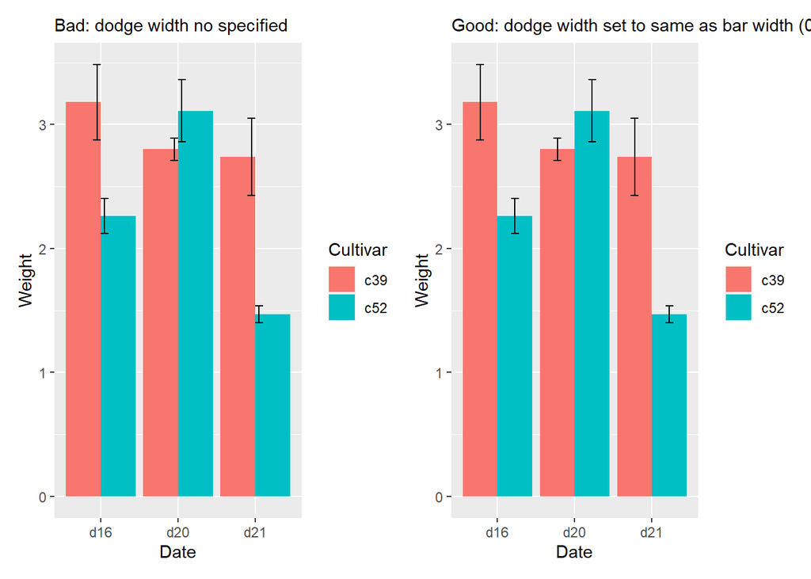

```r
fig_7151 <-
  cabbage_exp %>%
  ggplot(aes(x = Date, y = Weight, fill = Cultivar)) +
  geom_bar(stat = "identity", position = "dodge") +
  geom_errorbar(aes(ymin = Weight - se, ymax = Weight + se),
                position = "dodge", width = 0.2) +
  labs(subtitle = "Bad: dodge width no specified")

fig_7152 <-
  cabbage_exp %>%
  ggplot(aes(x = Date, y = Weight, fill = Cultivar)) +
  geom_bar(stat = "identity", position = "dodge") +
  geom_errorbar(aes(ymin = Weight - se, ymax = Weight + se),
                position = position_dodge(0.9),
                width = 0.2) +
  labs(subtitle = "Good: dodge width set to same as bar width (0.9)")

fig_7151 + fig_7152
```

line graph를 그릴 때는 error bar는 선이나 점과 다른 색을 적용한다면 error bar를 먼저 그려야 한다.  
그래야 error bar가 선이나 점 아래에 위치하기 때문이다.  
추가적으로 error bar를 정렬하기 위해서 모든 geometric element를 dodge 시켜야 한다.

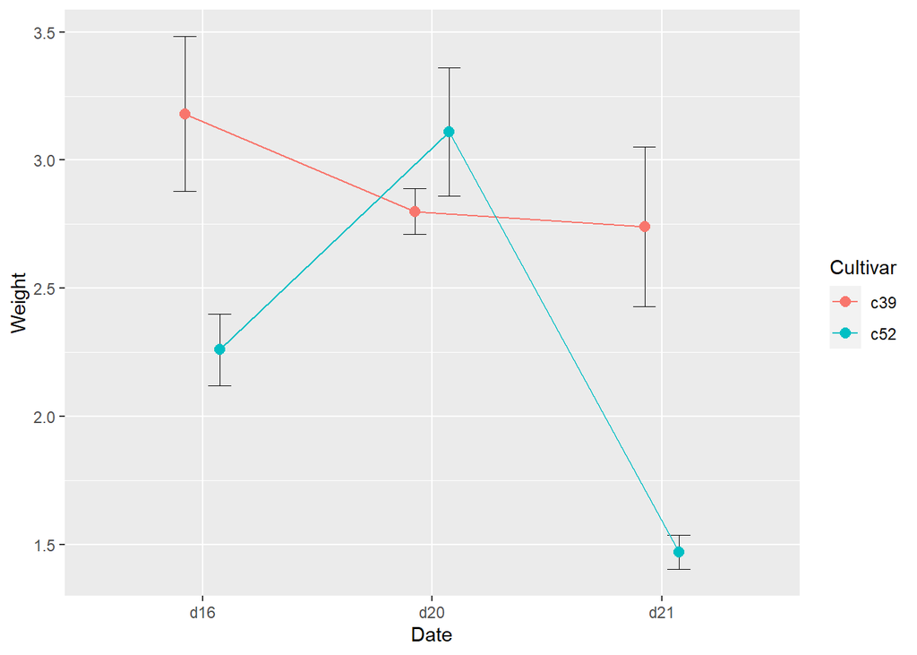

```r
pd <- position_dodge(0.3) # Save the dodge spec because we use it repeatedly

cabbage_exp %>%
  ggplot(aes(x = Date, y = Weight, color = Cultivar, group = Cultivar)) +
  geom_errorbar(aes(ymin = Weight - se, ymax = Weight + se),
                width = 0.2, size = 0.25, color = "#000000", position = pd) +
  geom_line(position = pd) +
  geom_point(position = pd, size = 2.5)
```

### 7.8 Adding annotations to indivisual facets

각 facet에 주석을 달기위해서는 `geom_text()`를 사용한다.

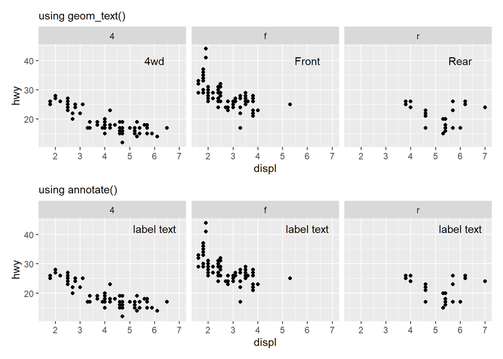

```r
# base plot
p <-
  mpg %>%
  ggplot(aes(x = displ, y = hwy)) +
  geom_point() +
  facet_wrap(~ drv)

# data frame with labels for each facet
f_labels <- data.frame(drv = c("4", "f", "r"), label = c("4wd", "Front", "Rear"))

fig_7171 <- p + geom_text(x = 6, y = 40, aes(label = label), data = f_labels) +
  labs(subtitle = "using geom_text()")

# If you use annotate(), the label will appear in all facets
fig_7172 <- p + annotate("text", x = 6, y = 42, label = "label text") +
  labs(subtitle = "using annotate()")

fig_7171 / fig_7172
```

주석이 아닌 각 facet의 제목으로 넣고 싶다면 아래와 같이 `labeller = as_labeller(...)`를 사용하는 것이 더 효과적임.

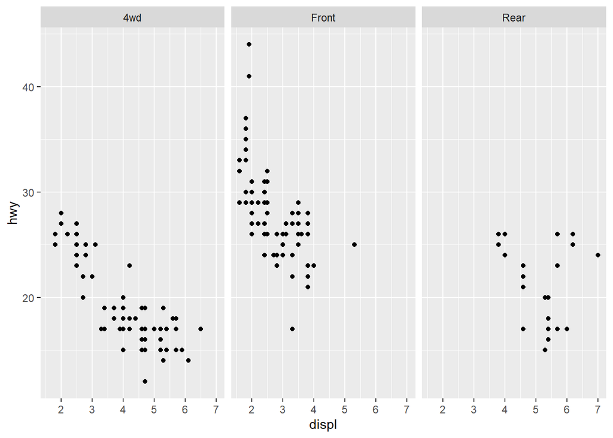

```r
mpg %>%
  ggplot(aes(x = displ, y = hwy)) +
  geom_point() +
  facet_wrap(~ drv, labeller = as_labeller(c('4' = "4wd", 'f' = "Front", 'r' = "Rear")))
```

각 facet별로 다른 주석을 보이는 기능이 유용한 경우는 각 facet별로 식이나 통계값을 나타낼 때이다.  
이렇게 하기 위해서는 사전에 필요한 값을 반환하는 함수를 만들어 두는 것이 필요하다.  
아래 예시는 각 facet별 회귀식과 결정계수($R^2$)를 나타내는 방법을 보여준다.  
`sprintf()`는 지정된 포맷에 순서대로 숫자를 입력하여 출력하는 함수이다.

```r
lm_labels <- function(dat) {
  mod <- lm(hwy ~ displ, data = dat)
  formula <- sprintf("italic(y) == %.2f %+.2f * italic(x)",
                     round(coef(mod)[1], 2), round(coef(mod)[2],2))
  r <- cor(dat$displ, dat$hwy)
  r2 <- sprintf("italic(R^2) == %.2f", r^2)
  data.frame(formula=formula, r2=r2, stringsAsFactors = FALSE)
}
```

```r
lables_book <- plyr::ddply(mpg, "drv", lm_labels)

lables_book
```

```
##   drv                              formula                  r2
## 1   4 italic(y) == 30.68 -2.88 * italic(x) italic(R^2) == 0.65
## 2   f italic(y) == 37.38 -3.60 * italic(x) italic(R^2) == 0.36
## 3   r italic(y) == 25.78 -0.92 * italic(x) italic(R^2) == 0.04
```

```r
labels <- mpg %>% group_by(drv) %>% do(lm_labels(.))

labels
```

```
## # A tibble: 3 x 3
## # Groups:   drv [3]
##   drv   formula                              r2
##   <chr> <chr>                                <chr>
## 1 4     italic(y) == 30.68 -2.88 * italic(x) italic(R^2) == 0.65
## 2 f     italic(y) == 37.38 -3.60 * italic(x) italic(R^2) == 0.36
## 3 r     italic(y) == 25.78 -0.92 * italic(x) italic(R^2) == 0.04
```

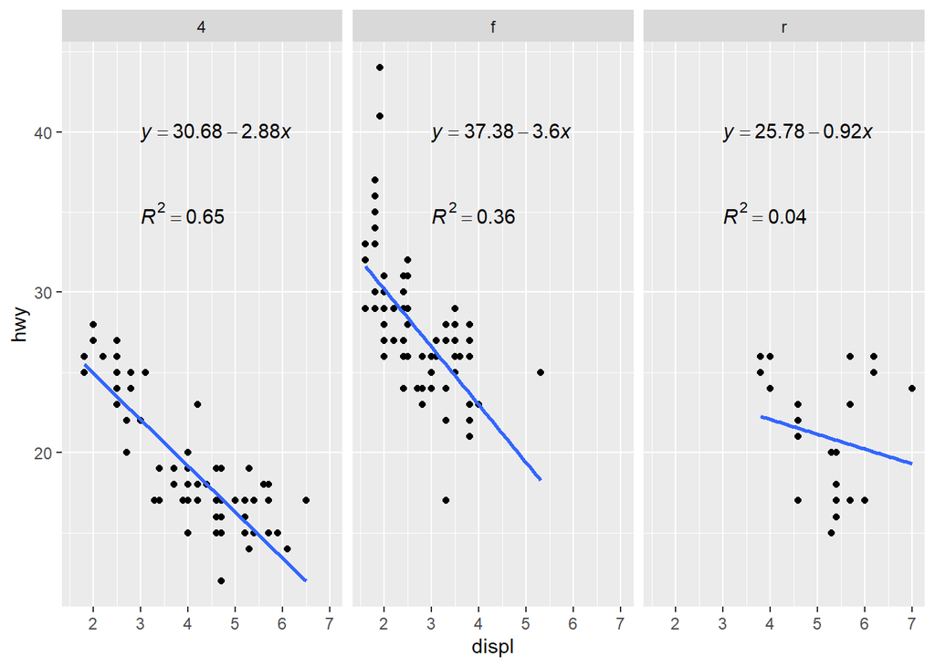

```r
p + geom_smooth(method = lm, se = FALSE) +
  geom_text(x = 3, y = 40, aes(label = formula), data = labels, parse = TRUE, hjust = 0) +
  geom_text(x = 3, y =35, aes(label = r2), data = labels, parse = TRUE, hjust = 0)
```

각 data frame에서 필요한 값을 바로 뽑아내는 것이 필요하기 때문에 함수를 만들었다.  
만약 결정계수($R^2$)만 필요한 경우라면 좀 더 간단하게 `summarise()`를 사용하여 필요한 것만 뽑아서 사용할 수 있다.

```r
simple_label <- plyr::ddply(mpg, "drv", summarise, r2 = cor(displ, hwy)^2)

simple_label
```

```
##   drv         r2
## 1   4 0.64591693
## 2   f 0.36040865
## 3   r 0.04100985
```

`dplyr()` package를 이용하여 구현

```r
mpg %>% group_by(drv) %>% summarise(r2 = cor(displ, hwy)^2)
```

```
## # A tibble: 3 x 2
##   drv       r2
##   <chr>  <dbl>
## 1 4     0.646
## 2 f     0.360
## 3 r     0.0410
```

```r
simple_label$r2 <- sprintf("italic(R^2) == %.2f", simple_label$r2)

simple_label
```

```
##   drv                  r2
## 1   4 italic(R^2) == 0.65
## 2   f italic(R^2) == 0.36
## 3   r italic(R^2) == 0.04
```

**END**